# Pre and Post Task Questionnaire

Haroon Popal

2025-11-12

## 0.1 Setup Up

### 0.1.1 Import Packages

```r
library(dplyr)
library(tidyr)
library(ggplot2)
library(emmeans)
library(lmerTest)
require(gridExtra)
library(multcomp)
library(plyr)
library(data.table)
library(stringi)
library(ggpubr)
library(sjPlot)
library(sjmisc)
library(sjlabelled)
library(lme4)
```

# 1 Post-Task Questionnaire

## 1.1 Clean Up

One issue with the questionnaire is that we are not sure who is the positive or negative peer. So we will import the psychopy data for each participant and verify whether “Charlie” or “Shiloh” is the positive or negative peer.

```r
redcap_report_list = list.files('derivatives/pre_post_task_survey/',
                                pattern="^SCONNPreAndPostTest-SRPreAndPostTaskQues_DATA",
                                full.names = TRUE)

# Import data
pre_post_data <- read.csv(redcap_report_list)

# Capitalize all participant IDs
pre_post_data$record_id <- toupper(pre_post_data$record_id)

# Only include participants with valid
pre_post_data <- pre_post_data[startsWith(pre_post_data$record_id, 'SCN_'),]

# Only include complete cases
pre_post_data <-pre_post_data[complete.cases(pre_post_data),]
```

### 1.1.1 Import PsychoPy Data

```r
pre_post_data$simpeer <- ''
pre_post_data$dispeer <- ''

for (subj in pre_post_data$record_id) {
  task_data_list = list.files(paste('derivatives/task_socialreward/data/',
                                    subj, '/', sep = ''),
                                  pattern="SR_SCN_*",
                                  full.names = TRUE)

  subj_simpeers <- list()
  subj_dispeers <- list()

  if (length(task_data_list) > 0) {
    for (run_file in task_data_list) {
      # Read the first file
      task_data <- read.csv(run_file)

      # Check which name is used for the similar peer condition
      task_simpeer_names <- task_data[task_data$ConditionName %like% "SimPeer", ]$peerName
      task_dispeer_names <- task_data[task_data$ConditionName %like% "DisPeer", ]$peerName

      run_simpeer <- unique(task_simpeer_names)
      run_dispeer <- unique(task_dispeer_names)

      subj_simpeers[length(subj_simpeers)+1] <- run_simpeer
      subj_dispeers[length(subj_dispeers)+1] <- run_dispeer
    }

    pre_post_data[pre_post_data$record_id == subj,]$simpeer <- unique(subj_simpeers[[1]])
    pre_post_data[pre_post_data$record_id == subj,]$dispeer <- unique(subj_dispeers[[1]])
  }
}

# Remove missing data
pre_post_data <- pre_post_data[pre_post_data$simpeer != '',]

print(paste("Number of participants with complete data: ",nrow(pre_post_data),
            sep=""))
```

```
## [1] "Number of participants with complete data: 148"
```

### 1.1.2 Visualize distribution of names

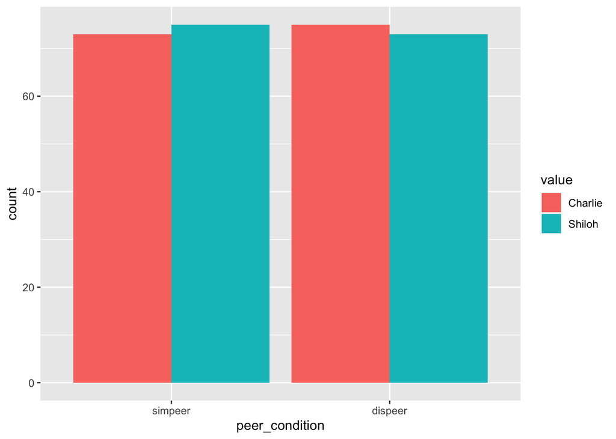

```r
peer_names_long <- melt(setDT(pre_post_data), id.vars = c("record_id"),
                        measure.vars =  c('simpeer','dispeer'),
                        variable.name = "peer_condition")

ggplot(peer_names_long, aes(x = peer_condition, fill = value))+geom_bar(position = 'dodge',
                                                                        stat = "count")
```

Double check the more recent participants

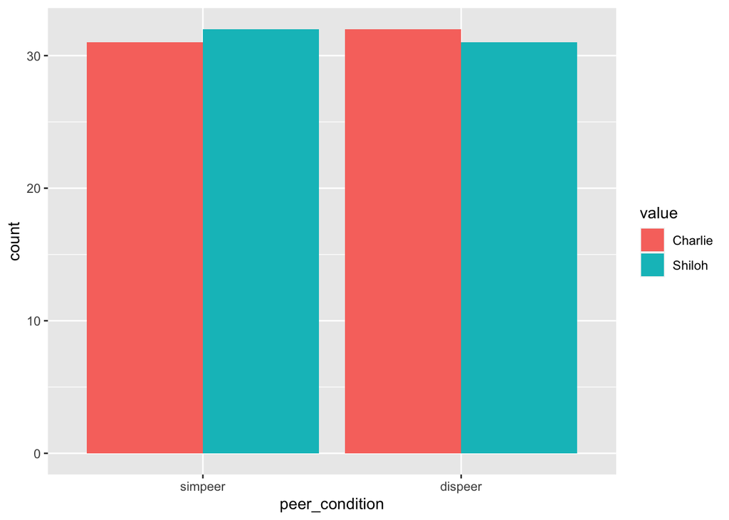

```r
peer_names_long_recent <- subset(peer_names_long, grepl("SCN_2", peer_names_long$record_id))

ggplot(peer_names_long_recent, aes(x = peer_condition, fill = value))+geom_bar(position = 'dodge',
                                                                        stat = "count")
```

### 1.1.3 Fixing Peer Names

One issue with this task is that peername1 and peername2 were arbitrarily assigned. These need to be recoded so that peername1 refers to the similar peer and peername2 refers to the dissimilar peer. Going forward, simpeer and dispeer will be used to refer to peername1 and peername2, respectively.

```r
pre_post_data_fx <- data.frame(simpeer = character(),
                               dispeer = character(),
                               learn_simpeer_pre = integer(),
                               learn_dispeer_pre = integer(),
                               time_simpeer_pre = integer(),
                               time_dispeer_pre = integer(),
                               similar_simpeer_pre = integer(),
                               similar_dispeer_pre = integer(),
                               feel_simpeer_post = integer(),
                               feel_dispeer_post = integer(),
                               common_simpeer_post = integer(),
                               common_dispeer_post = integer(),
                               time_simpeer_post = integer(),
                               time_dispeer_post = integer(),
                               learn_simpeer_post = integer(),
                               learn_dispeer_post = integer(),
                               learn_computer_post = integer(),
                               learn_most_post = character(),
                               thumbs_up_post = integer(),
                               thumbs_down_post = integer(),
                               check_mark_post = integer(),
                               x_post = integer(),
                               other_comments = character())




for (n in 1:nrow(pre_post_data)) {
  # Create an empty row
  pre_post_data_fx[n,] <- NA

  # Fill in data that doesn't change
  pre_post_data_fx$record_id[n] <- pre_post_data$record_id[n]
  pre_post_data_fx$learn_computer_post[n] <- pre_post_data$post9[n]
  pre_post_data_fx$learn_most_post[n] <- pre_post_data$post10[n]
  pre_post_data_fx$thumbs_up_post[n] <- pre_post_data$post11[n]
  pre_post_data_fx$thumbs_down_post[n] <- pre_post_data$post12[n]
  pre_post_data_fx$check_mark_post[n] <- pre_post_data$post13[n]
  pre_post_data_fx$x_post[n] <- pre_post_data$post14[n]
  pre_post_data_fx$other_comments[n] <- pre_post_data$post15[n]

  # If actual simpeer matches peername1, keep the same data
  if (pre_post_data$peername1[n] == pre_post_data$simpeer[n]) {
    pre_post_data_fx$simpeer[n] <- pre_post_data$simpeer[n]
    pre_post_data_fx$dispeer[n] <- pre_post_data$dispeer[n]
    pre_post_data_fx$learn_simpeer_pre[n] <- pre_post_data$pre1[n]
    pre_post_data_fx$learn_dispeer_pre[n] <- pre_post_data$pre2[n]
    pre_post_data_fx$time_simpeer_pre[n] <- pre_post_data$pre3[n]
    pre_post_data_fx$time_dispeer_pre[n] <- pre_post_data$pre4[n]
    pre_post_data_fx$similar_simpeer_pre[n] <- pre_post_data$pre5[n]
    pre_post_data_fx$similar_dispeer_pre[n] <- pre_post_data$pre6[n]
    pre_post_data_fx$feel_simpeer_post[n] <- pre_post_data$post1[n]
    pre_post_data_fx$feel_dispeer_post[n] <- pre_post_data$post2[n]
    pre_post_data_fx$common_simpeer_post[n] <- pre_post_data$post3[n]
    pre_post_data_fx$common_dispeer_post[n] <- pre_post_data$post4[n]
    pre_post_data_fx$time_simpeer_post[n] <- pre_post_data$post5[n]
    pre_post_data_fx$time_dispeer_post[n] <- pre_post_data$post6[n]
    pre_post_data_fx$learn_simpeer_post[n] <- pre_post_data$post7[n]
    pre_post_data_fx$learn_dispeer_post[n] <- pre_post_data$post8[n]
  } else if (pre_post_data$peername1[n] == pre_post_data$dispeer[n]) {
    pre_post_data_fx$simpeer[n] <- pre_post_data$dispeer[n]
    pre_post_data_fx$dispeer[n] <- pre_post_data$simpeer[n]
    pre_post_data_fx$learn_simpeer_pre[n] <- pre_post_data$pre2[n]
    pre_post_data_fx$learn_dispeer_pre[n] <- pre_post_data$pre1[n]
    pre_post_data_fx$time_simpeer_pre[n] <- pre_post_data$pre4[n]
    pre_post_data_fx$time_dispeer_pre[n] <- pre_post_data$pre3[n]
    pre_post_data_fx$similar_simpeer_pre[n] <- pre_post_data$pre6[n]
    pre_post_data_fx$similar_dispeer_pre[n] <- pre_post_data$pre5[n]
    pre_post_data_fx$feel_simpeer_post[n] <- pre_post_data$post2[n]
    pre_post_data_fx$feel_dispeer_post[n] <- pre_post_data$post1[n]
    pre_post_data_fx$common_simpeer_post[n] <- pre_post_data$post4[n]
    pre_post_data_fx$common_dispeer_post[n] <- pre_post_data$post3[n]
    pre_post_data_fx$time_simpeer_post[n] <- pre_post_data$post6[n]
    pre_post_data_fx$time_dispeer_post[n] <- pre_post_data$post5[n]
    pre_post_data_fx$learn_simpeer_post[n] <- pre_post_data$post8[n]
    pre_post_data_fx$learn_dispeer_post[n] <- pre_post_data$post7[n]
  }
}
```

```r
# Convert to long format
pre_post_data_long <- melt(setDT(pre_post_data_fx), id.vars = c("record_id"), variable.name = "question")
# Convert values to be numeric
pre_post_data_long$value <- as.numeric(pre_post_data_long$value)
head(pre_post_data_long)
```

| record_id | question | value |
| --- | --- | --- |
| SCN_101 | simpeer | NA |
| SCN_102 | simpeer | NA |
| SCN_103 | simpeer | NA |
| SCN_104 | simpeer | NA |
| SCN_105 | simpeer | NA |
| SCN_106 | simpeer | NA |

pre1: How much are you interested in learning about [peername1]? pre2: How much are you interested in learning about [peername2]? pre3: How much do you think you would want to spend time with [peername1] if you knew them in real life? pre4: How much do you think you would want to spend time with [peername2] if you knew them in real life? pre5: How similar do you think you are to [peername1]? pre6: How similar do you think you are to [peername2]? post1: How do you feel about [peername1]? post2: How do you feel about [peername2]? post3: How much do you have in common with [peername1]? post4: How much do you have in common with [peername2]? post5: How much would you want to spend time with [peername1] if you knew them in real life? post6: How much would you want to spend time with [peername2] if you knew them in real life? post7: How much did you want to learn about [peername1]? post8: How much did you want to learn about [peername2]? post9: How much did you want to learn about the computer? post10: Who or what did you like learning about the most? post11: How did it feel when you got a thumbs up? post12: How did it feel when you got a thumbs down? post13: How did it feel when you got a check mark? post14: How did it feel when you got a X? post15: Is there anything else you want to tell us about the task?

### 1.1.4 Add original questions

Split variable names

```r
pre_post_data_long$time_point <- ""
pre_post_data_long$peer <- ""
#pre_post_data_long$item <- ""

for (n in 1:nrow(pre_post_data_long)) {
  if (grepl( 'pre', pre_post_data_long$question[n], fixed = TRUE)) {
    pre_post_data_long$time_point[n] <- 'pre'
  } else if (grepl( 'post', pre_post_data_long$question[n], fixed = TRUE)) {
    pre_post_data_long$time_point[n] <- 'post'
  }

  if (grepl( 'simpeer', pre_post_data_long$question[n], fixed = TRUE)) {
    pre_post_data_long$peer[n] <- 'similar'
  } else if (grepl( 'dispeer', pre_post_data_long$question[n], fixed = TRUE)) {
    pre_post_data_long$peer[n] <- 'dissimilar'
  }

  #pre_post_data_long$item[n] <- stri_sub(pre_post_data_long$question[n], -1)
}
```

# 2 Results

## 2.1 Feedback Value

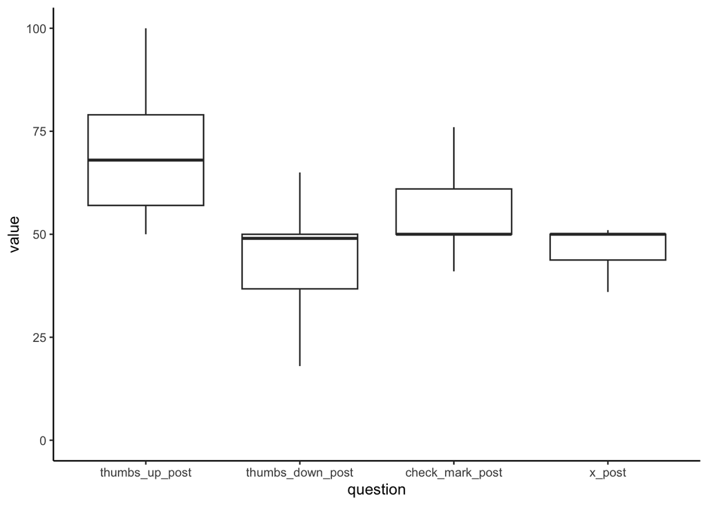

```r
ggplot(data = subset(pre_post_data_long, question %in% c('thumbs_up_post', 'thumbs_down_post',
                                                         'check_mark_post','x_post')),
                aes(x=question, y=value)) +
         geom_boxplot(outlier.shape = NA) +
         theme_classic()
```

## 2.2 Pre and Post Peer Sentiment

```r
pre_post_data_long_clean <- data.frame(pre_post_data_long)
pre_post_data_long_clean <- pre_post_data_long_clean[complete.cases(pre_post_data_long_clean), ]

# Remove substring
pre_post_data_long_clean$question <- gsub("_pre", "", pre_post_data_long_clean$question)
pre_post_data_long_clean$question <- gsub("_post", "", pre_post_data_long_clean$question)

head(pre_post_data_long_clean)
```

|  | record_id | question | value | time_point | peer |
| --- | --- | --- | --- | --- | --- |
| 297 | SCN_101 | learn_simpeer | 97 | pre | similar |
| 298 | SCN_102 | learn_simpeer | 73 | pre | similar |
| 299 | SCN_103 | learn_simpeer | 91 | pre | similar |
| 300 | SCN_104 | learn_simpeer | 53 | pre | similar |
| 301 | SCN_105 | learn_simpeer | 50 | pre | similar |
| 302 | SCN_106 | learn_simpeer | 50 | pre | similar |

### 2.2.1 ANOVA

Create a separate dataframe from each question

```r
data_learn <- subset(pre_post_data_long_clean,
                     question %in% c('learn_simpeer', 'learn_dispeer'))

data_time <- subset(pre_post_data_long_clean,
                    question %in% c('time_simpeer', 'time_dispeer'))

data_similar <- subset(pre_post_data_long_clean,
                       question %in% c('similar_simpeer', 'similar_dispeer',
                                       'common_simpeer','common_dispeer'))

data_valence <- subset(pre_post_data_long_clean,
                       question %in% c('feel_simpeer', 'feel_dispeer'))
```

```r
mod_learn <- lmer(value ~ peer*time_point + (1 | record_id),
                       data=data_learn)
mod_time <- lmer(value ~ peer*time_point + (1 | record_id),
                       data=data_time)
mod_similar <- lmer(value ~ peer*time_point + (1 | record_id),
                       data=data_similar)
mod_valence <- lmer(value ~ peer + (1 | record_id),
                       data=data_valence)

# Convert the class of the lmer output
#class(mod_learn) <- "lmerMod"
#class(mod_time) <- "lmerMod"
#class(mod_similar) <- "lmerMod"
#class(mod_valence) <- "lmerMod"

tab_model(mod_learn, mod_time, mod_similar, mod_valence,
          dv.labels = c("Interest in Learning", "Spending Time", "Similarity",
                        'Valence'),
          file = 'derivatives/pre_post_task_survey/pre_post_anova_table.html')
```

|  | Interest in Learning |  |  | Spending Time |  |  | Similarity |  |  | Valence |  |  |
| --- | --- | --- | --- | --- | --- | --- | --- | --- | --- | --- | --- | --- |
| Predictors | Estimates | CI | p | Estimates | CI | p | Estimates | CI | p | Estimates | CI | p |
| (Intercept) | 57.52 | 54.50 – 60.55 | **<0.001** | 45.60 | 42.73 – 48.47 | **<0.001** | 43.54 | 40.56 – 46.52 | **<0.001** | 52.05 | 49.24 – 54.86 | **<0.001** |
| peer [similar] | 7.23 | 4.24 – 10.23 | **<0.001** | 16.73 | 13.35 – 20.12 | **<0.001** | 25.92 | 21.92 – 29.93 | **<0.001** | 15.61 | 11.70 – 19.52 | **<0.001** |
| time point [pre] | 4.57 | 1.58 – 7.56 | **0.003** | 9.31 | 5.93 – 12.70 | **<0.001** | 9.15 | 5.15 – 13.16 | **<0.001** |  |  |  |
| peer [similar] × time point [pre] | -6.62 | -10.85 – -2.39 | **0.002** | -17.77 | -22.55 – -12.98 | **<0.001** | -28.41 | -34.07 – -22.74 | **<0.001** |  |  |  |
| Random Effects |  |  |  |  |  |  |  |  |  |  |  |  |
| σ<sup>2</sup> | 168.26 |  |  | 215.37 |  |  | 301.65 |  |  | 286.15 |  |  |
| τ<sub>00</sub> | 174.97 <sub>record_id</sub> |  |  | 94.16 <sub>record_id</sub> |  |  | 32.12 <sub>record_id</sub> |  |  | 9.92 <sub>record_id</sub> |  |  |
| ICC | 0.51 |  |  | 0.30 |  |  | 0.10 |  |  | 0.03 |  |  |
| N | 145 <sub>record_id</sub> |  |  | 145 <sub>record_id</sub> |  |  | 145 <sub>record_id</sub> |  |  | 145 <sub>record_id</sub> |  |  |
| Observations | 580 |  |  | 580 |  |  | 580 |  |  | 290 |  |  |
| Marginal R<sup>2</sup> / Conditional R<sup>2</sup> | 0.020 / 0.520 |  |  | 0.102 / 0.375 |  |  | 0.215 / 0.290 |  |  | 0.171 / 0.199 |  |  |

### 2.2.2 Visualization

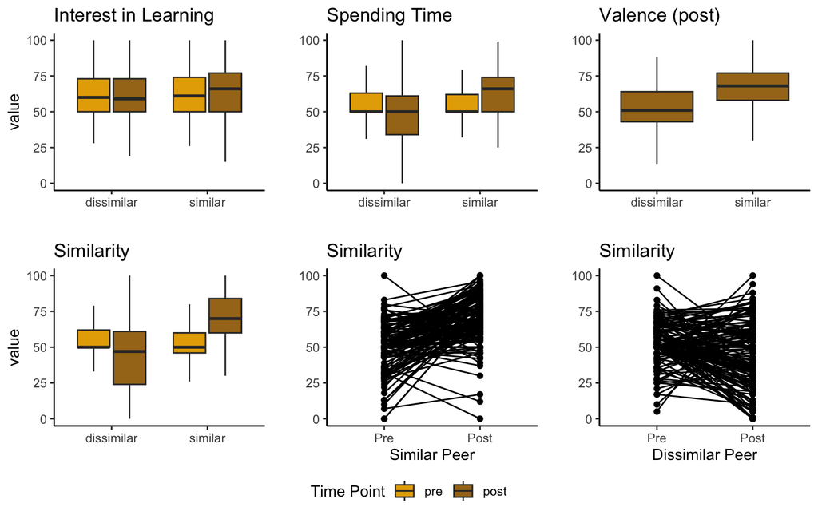

```r
# Define color palette
color_palette <- c("#E6AB02","#A6761D")


# Reorder variable for plotting
pre_post_data_long_clean$time_point <- factor(pre_post_data_long_clean$time_point,
                                              levels = c("pre", "post"))


plot1 <- ggplot(data = subset(pre_post_data_long_clean,
                              question %in% c('learn_simpeer', 'learn_dispeer')),
                aes(x=peer, y=value, fill=time_point, z=question)) +
         geom_boxplot(outlier.shape = NA) +
         theme_classic() +
         theme(legend.position="none") +
         ggtitle("Interest in Learning") +
         xlab("") +
         scale_fill_manual(values = color_palette) +
         labs(fill = 'Time Point')
         #scale_color_grey(start = 0.5, end = 0.2)

plot2 <- ggplot(data = subset(pre_post_data_long_clean,
                              question %in% c('time_simpeer', 'time_dispeer')),
                aes(x=peer, y=value, fill=time_point, z=question)) +
         geom_boxplot(outlier.shape = NA) +
         theme_classic() +
         theme(legend.position="none") +
         ggtitle("Spending Time") +
         xlab("") +
         ylab("") +
         scale_fill_manual(values = color_palette) +
         labs('Time Point')
         #scale_x_discrete(labels=c("Pre","Pre","Post","Post")) +
         #scale_fill_brewer(palette="Dark2") +


plot3 <- ggplot(data = subset(pre_post_data_long_clean,
                              question %in% c('similar_simpeer', 'similar_dispeer',
                                              'common_simpeer','common_dispeer')),
                aes(x=peer, y=value, fill=time_point, z=question)) +
         geom_boxplot(outlier.shape = NA) +
         theme_classic() +
         theme(legend.position="none") +
         ggtitle("Similarity") +
         xlab("") +
         scale_fill_manual(values = color_palette)

plot4 <- ggplot(data = subset(pre_post_data_long_clean, question %in% c('similar_simpeer',
                                                                  'common_simpeer')),
                aes(x=time_point, y=value, group=record_id)) +
         geom_point() +
         geom_line() +
         theme_classic() +
         scale_x_discrete(name ="Similar Peer", labels=c("Pre","Post")) +
         theme(legend.position="none") +
         ggtitle("Similarity") +
         scale_fill_manual(values = color_palette) +
         ylab("")

plot5 <- ggplot(data = subset(pre_post_data_long_clean, question %in% c('similar_dispeer',
                                                                  'common_dispeer')),
                aes(x=time_point, y=value, group=record_id)) +
         geom_point() +
         geom_line() +
         theme_classic() +
         scale_x_discrete(name ="Dissimilar Peer", labels=c("Pre","Post")) +
         theme(legend.position="none") +
         ggtitle("Similarity") +
         scale_fill_manual(values = color_palette) +
         ylab("")


plot6 <- ggplot(data = subset(pre_post_data_long_clean, question %in% c('feel_simpeer', 'feel_dispeer')),
                aes(x=peer, y=value, z=question, fill=time_point)) +
         geom_boxplot(outlier.shape = NA) +
         theme_classic() +
         ggtitle("Valence (post)") +
         xlab("") +
         #theme(axis.text.x = element_blank()) +
         scale_fill_manual(values = c("#A6761D")) +
         ylab("")

common_legend <- get_legend(plot1)

ggarrange(plot1, plot2, plot6,
          plot3, plot4, plot5,
          ncol=3, nrow=2, common.legend = TRUE, legend="bottom")
```

## 2.3 Create a list of the “learners”

```r
sim_learn <- pre_post_data_fx[pre_post_data_fx$common_simpeer_post > pre_post_data_fx$similar_simpeer_pre,]
print(nrow(sim_learn))
```

```
## [1] 116
```

```r
head(sim_learn[,c('record_id','similar_simpeer_pre', 'common_simpeer_post')])
```

| record_id | similar_simpeer_pre | common_simpeer_post |
| --- | --- | --- |
| SCN_102 | 61 | 92 |
| SCN_103 | 50 | 84 |
| SCN_104 | 43 | 61 |
| SCN_106 | 29 | 57 |
| SCN_107 | 50 | 75 |
| SCN_108 | 0 | 76 |

```r
dis_learn <- pre_post_data_fx[pre_post_data_fx$common_dispeer_post > pre_post_data_fx$similar_dispeer_pre,]
print(nrow(dis_learn))
```

```
## [1] 54
```

```r
write.csv(pre_post_data_fx, 'derivatives/pre_post_task_survey/pre_post_survey_clean.csv')

head(dis_learn[,c('record_id','similar_dispeer_pre', 'common_dispeer_post')])
```

| record_id | similar_dispeer_pre | common_dispeer_post |
| --- | --- | --- |
| SCN_101 | 73 | 84 |
| SCN_104 | 43 | 54 |
| SCN_107 | 57 | 63 |
| SCN_109 | 17 | 50 |
| SCN_112 | 50 | 57 |
| SCN_120 | 74 | 76 |

```r
all_learn <- merge(sim_learn, dis_learn, by = 'record_id')
print(nrow(all_learn))
```

```
## [1] 47
```

```r
head(all_learn)
```

| record_id | simpeer.x | dispeer.x | learn_simpeer_pre.x | learn_dispeer_pre.x | time_simpeer_pre.x | time_dispeer_pre.x | similar_simpeer_pre.x | similar_dispeer_pre.x | feel_simpeer_post.x | feel_dispeer_post.x | common_simpeer_post.x | common_dispeer_post.x | time_simpeer_post.x | time_dispeer_post.x | learn_simpeer_post.x | learn_dispeer_post.x | learn_computer_post.x | learn_most_post.x | thumbs_up_post.x | thumbs_down_post.x | check_mark_post.x | x_post.x | other_comments.x | simpeer.y | dispeer.y | learn_simpeer_pre.y | learn_dispeer_pre.y | time_simpeer_pre.y | time_dispeer_pre.y | … |
| --- | --- | --- | --- | --- | --- | --- | --- | --- | --- | --- | --- | --- | --- | --- | --- | --- | --- | --- | --- | --- | --- | --- | --- | --- | --- | --- | --- | --- | --- | --- |
| SCN_104 | Charlie | Shiloh | 53 | 53 | 33 | 32 | 43 | 43 | 78 | 63 | 61 | 54 | 54 | 23 | 81 | 81 | 100 | 3 | 74 | 36 | 50 | 50 | Thought the computer questions were entertaining. Wanted to guess what the computer would say even though sometimes it wouldn't make sense. | Charlie | Shiloh | 53 | 53 | 33 | 32 | … |
| SCN_107 | Shiloh | Charlie | 50 | 50 | 50 | 50 | 50 | 57 | 73 | 65 | 75 | 63 | 66 | 54 | 71 | 80 | 50 | 1 | 72 | 50 | 50 | 50 |  | Shiloh | Charlie | 50 | 50 | 50 | 50 | … |
| SCN_109 | Charlie | Shiloh | 50 | 50 | 50 | 50 | 18 | 17 | 71 | 52 | 80 | 50 | 79 | 77 | 50 | 50 | 100 | 3 | 100 | 28 | 100 | 16 |  | Charlie | Shiloh | 50 | 50 | 50 | 50 | … |
| SCN_112 | Shiloh | Charlie | 50 | 50 | 54 | 54 | 50 | 50 | 62 | 62 | 64 | 57 | 69 | 50 | 74 | 63 | 32 | 2 | 97 | 50 | 61 | 50 |  | Shiloh | Charlie | 50 | 50 | 54 | 54 | … |
| SCN_120 | Shiloh | Charlie | 75 | 76 | 59 | 59 | 72 | 74 | 69 | 69 | 77 | 76 | 64 | 61 | 71 | 70 | 50 | 2 | 63 | 50 | 50 | 50 |  | Shiloh | Charlie | 75 | 76 | 59 | 59 | … |
| SCN_122 | Shiloh | Charlie | 78 | 76 | 45 | 47 | 37 | 35 | 73 | 71 | 64 | 62 | 66 | 62 | 71 | 71 | 29 | 1 | 71 | 30 | 61 | 40 |  | Shiloh | Charlie | 78 | 76 | 45 | 47 | … |

### 2.3.1 Export participant list for “Learners”

```r
# Import original participants list
participants_orig <- read.csv('participants.tsv', sep = '\t')

# Add prefix to match subject ids
sim_learn$participant_id <- paste0('sub-', sim_learn$record_id)

# Remove underscore from subject ids
sim_learn$participant_id <- gsub("_", "", sim_learn$participant_id)

# Filter for only participants who learned the similar peer
participants_sim_learn <- participants_orig[participants_orig$participant_id %in% sim_learn$participant_id, ]

# Export
write.csv(participants_sim_learn, 'derivatives/pre_post_task_survey/participants-task-sim_learn.csv',
          row.names = FALSE)
```

```r
# Import original participants list
participants_orig <- read.csv('participants.tsv', sep = '\t')

# Add prefix to match subject ids
dis_learn$participant_id <- paste0('sub-', dis_learn$record_id)

# Remove underscore from subject ids
dis_learn$participant_id <- gsub("_", "", dis_learn$participant_id)

# Filter for only participants who learned the similar peer
participants_dis_learn <- participants_orig[participants_orig$participant_id %in% dis_learn$participant_id, ]

# Export
write.csv(participants_dis_learn, 'derivatives/pre_post_task_survey/participants-task-dis_learn.csv',
          row.names = FALSE)
```

# 3 Group Differences

```r
# Import group identifiers
demo_info <- read.csv('participants.tsv', sep = '\t')

# Remove 'sub-' prefix from participant IDs
demo_info$participant_id<-gsub("sub-","",as.character(demo_info$participant_id))
demo_info$participant_id<-gsub("SCN","SCN_",as.character(demo_info$participant_id))

# Rename group labels
demo_info$group[demo_info$group == 1] <- 'N-AUT'
demo_info$group[demo_info$group == 2] <- 'AUT'

head(demo_info)
```

|  | participant_id | age | gender | group |
| --- | --- | --- | --- | --- |
| 1 | SCN_101 | 13.29 | 2 | N-AUT |
| 2 | SCN_102 | 12.38 | 1 | N-AUT |
| 3 | SCN_103 | 11.55 | 2 | N-AUT |
| 4 | SCN_104 | 12.42 | 1 | N-AUT |
| 5 | SCN_105 | 14.39 | 4 | AUT |
| 6 | SCN_106 | 12.40 | 1 | N-AUT |

```r
pre_post_data_long_clean$group <- ''

for (subj_id in unique(pre_post_data_long_clean$record_id)) {
  if (nrow(demo_info[demo_info$participant_id == subj_id, ]) == 0) {
    next
  } else {
    temp_group <- demo_info[demo_info$participant_id == subj_id, ]$group

    pre_post_data_long_clean[pre_post_data_long_clean$record_id == subj_id, ]$group <- temp_group
  }
}
```

## 3.1 ANOVA

Create a separate dataframe from each question

```r
data_learn <- subset(pre_post_data_long_clean,
                     question %in% c('learn_simpeer', 'learn_dispeer'))

data_time <- subset(pre_post_data_long_clean,
                    question %in% c('time_simpeer', 'time_dispeer'))

data_similar <- subset(pre_post_data_long_clean,
                       question %in% c('similar_simpeer', 'similar_dispeer',
                                       'common_simpeer','common_dispeer'))

data_valence <- subset(pre_post_data_long_clean,
                       question %in% c('feel_simpeer', 'feel_dispeer'))
```

```r
mod_learn_group <- lmer(value ~ peer*time_point*group + (1 | record_id),
                       data=data_learn)
mod_time_group <- lmer(value ~ peer*time_point*group + (1 | record_id),
                       data=data_time)
mod_similar_group <- lmer(value ~ peer*time_point*group + (1 | record_id),
                       data=data_similar)
mod_valence_group <- lmer(value ~ peer*group + (1 | record_id),
                       data=data_valence)

# Convert the class of the lmer output
#class(mod_learn) <- "lmerMod"
#class(mod_time) <- "lmerMod"
#class(mod_similar) <- "lmerMod"
#class(mod_valence) <- "lmerMod"

tab_model(mod_learn_group, mod_time_group, mod_similar_group, mod_valence_group,
          dv.labels = c("Interest in Learning", "Spending Time", "Similarity",
                        'Valence'),
          file = 'derivatives/pre_post_task_survey/pre_post_anova_table_group.html')
```

|  | Interest in Learning |  |  | Spending Time |  |  | Similarity |  |  | Valence |  |  |
| --- | --- | --- | --- | --- | --- | --- | --- | --- | --- | --- | --- | --- |
| Predictors | Estimates | CI | p | Estimates | CI | p | Estimates | CI | p | Estimates | CI | p |
| (Intercept) | 63.75 | 45.50 – 82.00 | **<0.001** | 57.75 | 40.55 – 74.95 | **<0.001** | 44.50 | 26.70 – 62.30 | **<0.001** | 59.25 | 42.34 – 76.16 | **<0.001** |
| peer [similar] | -9.00 | -26.99 – 8.99 | 0.326 | -3.50 | -23.64 – 16.64 | 0.733 | 0.25 | -23.69 – 24.19 | 0.984 | -4.25 | -27.57 – 19.07 | 0.720 |
| time point [post] | -2.00 | -19.99 – 15.99 | 0.827 | -8.50 | -28.64 – 11.64 | 0.408 | 4.00 | -19.94 – 27.94 | 0.743 |  |  |  |
| group [AUT] | -1.57 | -20.63 – 17.50 | 0.872 | -0.23 | -18.19 – 17.74 | 0.980 | 5.91 | -12.68 – 24.50 | 0.533 | -5.95 | -23.61 – 11.70 | 0.507 |
| group [N-AUT] | -1.76 | -20.39 – 16.87 | 0.853 | -4.14 | -21.69 – 13.41 | 0.643 | 9.57 | -8.59 – 27.73 | 0.301 | -8.06 | -25.32 – 9.19 | 0.358 |
| peer [similar] × time point [post] | -0.50 | -25.94 – 24.94 | 0.969 | -3.50 | -31.99 – 24.99 | 0.809 | 3.75 | -30.11 – 37.61 | 0.828 |  |  |  |
| peer [similar] × group [AUT] | 11.39 | -7.40 – 30.17 | 0.234 | 3.73 | -17.31 – 24.77 | 0.728 | -2.75 | -27.76 – 22.26 | 0.829 | 16.27 | -8.08 – 40.62 | 0.189 |
| peer [similar] × group [N-AUT] | 9.21 | -9.15 – 27.56 | 0.325 | 1.99 | -18.56 – 22.55 | 0.849 | -2.84 | -27.27 – 21.59 | 0.820 | 22.30 | -1.49 – 46.09 | 0.066 |
| time point [post] × group [AUT] | -4.93 | -23.72 – 13.85 | 0.606 | -1.55 | -22.58 – 19.49 | 0.885 | -8.45 | -33.46 – 16.55 | 0.507 |  |  |  |
| time point [post] × group [N-AUT] | -1.61 | -19.96 – 16.74 | 0.863 | -0.51 | -21.06 – 20.04 | 0.961 | -15.82 | -40.26 – 8.61 | 0.204 |  |  |  |
| (peer [similar] × time point [post]) × group [AUT] | 8.39 | -18.18 – 34.95 | 0.535 | 15.50 | -14.25 – 45.25 | 0.307 | 16.14 | -19.23 – 51.50 | 0.371 |  |  |  |
| (peer [similar] × time point [post]) × group [N-AUT] | 6.84 | -19.11 – 32.80 | 0.605 | 24.76 | -4.31 – 53.82 | 0.095 | 29.54 | -5.01 – 64.09 | 0.094 |  |  |  |
| Random Effects |  |  |  |  |  |  |  |  |  |  |  |  |
| σ<sup>2</sup> | 167.70 |  |  | 210.32 |  |  | 297.20 |  |  | 280.59 |  |  |
| τ<sub>00</sub> | 177.79 <sub>record_id</sub> |  |  | 96.38 <sub>record_id</sub> |  |  | 31.25 <sub>record_id</sub> |  |  | 14.46 <sub>record_id</sub> |  |  |
| ICC | 0.51 |  |  | 0.31 |  |  | 0.10 |  |  | 0.05 |  |  |
| N | 145 <sub>record_id</sub> |  |  | 145 <sub>record_id</sub> |  |  | 145 <sub>record_id</sub> |  |  | 145 <sub>record_id</sub> |  |  |
| Observations | 580 |  |  | 580 |  |  | 580 |  |  | 290 |  |  |
| Marginal R<sup>2</sup> / Conditional R<sup>2</sup> | 0.027 / 0.528 |  |  | 0.121 / 0.397 |  |  | 0.235 / 0.308 |  |  | 0.183 / 0.223 |  |  |

## 3.2 Visualization

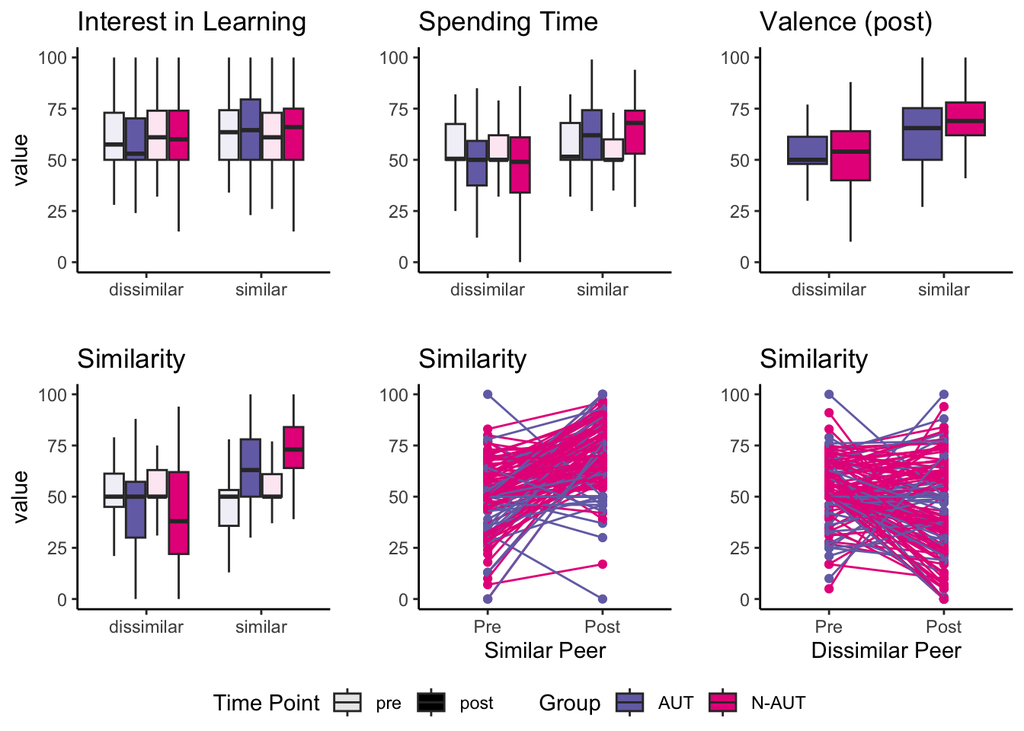

```r
# Define color palette
color_palette <- c("#7570B3", "#E7298A")

# Make a subset of data without blank group data
pre_post_data_long_group <- pre_post_data_long_clean[pre_post_data_long_clean$group != "",]

plot1 <- ggplot(data = subset(pre_post_data_long_group,
                              question %in% c('learn_simpeer', 'learn_dispeer')),
                aes(x=peer, y=value, fill=group, alpha=factor(time_point), z=question)) +
         geom_boxplot(outlier.shape = NA) +
         theme_classic() +
         theme(legend.position="none") +
         ggtitle("Interest in Learning") +
         xlab("") +
         scale_fill_manual(values = color_palette) +
         scale_alpha_discrete(guide = guide_legend(override.aes = list(fill = "black"))) +
         labs(alpha = 'Time Point', fill = 'Group')
plot2 <- ggplot(data = subset(pre_post_data_long_group,
                              question %in% c('time_simpeer', 'time_dispeer')),
                aes(x=peer, y=value, fill=group, alpha=time_point, z=question)) +
         geom_boxplot(outlier.shape = NA) +
         theme_classic() +
         theme(legend.position="none") +
         ggtitle("Spending Time") +
         xlab("") +
         scale_fill_manual(values = color_palette) +
         ylab("")

plot3 <- ggplot(data = subset(pre_post_data_long_group,
                              question %in% c('similar_simpeer', 'similar_dispeer',
                                              'common_simpeer','common_dispeer')),
                aes(x=peer, y=value, fill=group, alpha=time_point, z=question)) +
         geom_boxplot(outlier.shape = NA) +
         theme_classic() +
         theme(legend.position="none") +
         ggtitle("Similarity") +
         xlab("") +
         scale_fill_manual(values = color_palette)

plot4 <- ggplot(data = subset(pre_post_data_long_group,
                              question %in% c('similar_simpeer', 'common_simpeer')),
                aes(x=time_point, y=value, group=record_id, color=group)) +
         geom_point() +
         geom_line() +
         theme_classic() +
         scale_x_discrete(name ="Similar Peer", labels=c("Pre","Post")) +
         theme(legend.position="none") +
         ggtitle("Similarity") +
         scale_color_manual(values = color_palette) +
         ylab("")

plot5 <- ggplot(data = subset(pre_post_data_long_group,
                              question %in% c('similar_dispeer', 'common_dispeer')),
                aes(x=time_point, y=value, group=record_id, color=group)) +
         geom_point() +
         geom_line() +
         theme_classic() +
         scale_x_discrete(name ="Dissimilar Peer", labels=c("Pre","Post")) +
         theme(legend.position="none") +
         ggtitle("Similarity") +
         scale_color_manual(values = color_palette) +
         ylab("")


plot6 <- ggplot(data = subset(pre_post_data_long_group,
                              question %in% c('feel_simpeer', 'feel_dispeer')),
                aes(x=peer, y=value, fill=group, z=question)) +
         geom_boxplot(outlier.shape = NA) +
         theme_classic() +
         ggtitle("Valence (post)") +
         xlab("") +
         scale_fill_manual(values = color_palette) +
         ylab("")



ggarrange(plot1, plot2, plot6,
          plot3, plot4, plot5,
          ncol=3, nrow=2, common.legend = TRUE, legend = 'bottom')
```

# 4 PsychoPy Task Error Analysis

Are there differences between participants who had task errors and those that did not?

```r
# Import task error data
task_errors <- read.csv('derivatives/task_socialreward/data/answer_errors_sum.csv')

task_errors$num_errors <- as.numeric(task_errors$num_errors)

head(task_errors)
```

|  | X | num_errors |
| --- | --- | --- |
| 1 | SCN_101 | 0 |
| 2 | SCN_102 | 0 |
| 3 | SCN_103 | 0 |
| 4 | SCN_104 | 0 |
| 5 | SCN_105 | 0 |
| 6 | SCN_106 | 0 |

```r
pre_post_data_long_clean$errors <- ''

for (n_row in 1:nrow(pre_post_data_long_clean)) {
  temp_subj_id <- pre_post_data_long_clean$record_id[n_row]

  if (temp_subj_id %in% task_errors$X) {
      temp_n_errors <- task_errors[task_errors$X == temp_subj_id, 'num_errors']


  if (temp_n_errors > 0) {
    pre_post_data_long_clean[n_row, 'errors'] <- 'some'
  } else {
    pre_post_data_long_clean[n_row, 'errors'] <- 'none'
  }
  }

}

pre_post_data_long_error <- pre_post_data_long_clean[pre_post_data_long_clean$error != "",]
```

## 4.1 ANOVA

Create a separate dataframe from each question

```r
data_learn_error <- subset(pre_post_data_long_error,
                     question %in% c('learn_simpeer', 'learn_dispeer'))

data_time_error <- subset(pre_post_data_long_error,
                    question %in% c('time_simpeer', 'time_dispeer'))

data_similar_error <- subset(pre_post_data_long_error,
                       question %in% c('similar_simpeer', 'similar_dispeer',
                                       'common_simpeer','common_dispeer'))

data_valence_error <- subset(pre_post_data_long_error,
                       question %in% c('feel_simpeer', 'feel_dispeer'))
```

```r
mod_learn_error <- lmer(value ~ peer*time_point*errors + (1 | record_id),
                       data=data_learn_error)
mod_time_error <- lmer(value ~ peer*time_point*errors + (1 | record_id),
                       data=data_time_error)
mod_similar_error <- lmer(value ~ peer*time_point*errors + (1 | record_id),
                       data=data_similar_error)
mod_valence_error <- lmer(value ~ peer*errors + (1 | record_id),
                       data=data_valence_error)


tab_model(mod_learn_error, mod_time_error, mod_similar_error, mod_valence_error,
          dv.labels = c("Interest in Learning", "Spending Time", "Similarity",
                        'Valence'),
          file = 'derivatives/pre_post_task_survey/pre_post_anova_table_error.html')
```

|  | Interest in Learning |  |  | Spending Time |  |  | Similarity |  |  | Valence |  |  |
| --- | --- | --- | --- | --- | --- | --- | --- | --- | --- | --- | --- | --- |
| Predictors | Estimates | CI | p | Estimates | CI | p | Estimates | CI | p | Estimates | CI | p |
| (Intercept) | 61.27 | 57.60 – 64.93 | **<0.001** | 56.05 | 52.60 – 59.50 | **<0.001** | 52.13 | 48.54 – 55.72 | **<0.001** | 50.64 | 47.24 – 54.04 | **<0.001** |
| peer [similar] | -0.03 | -3.62 – 3.56 | 0.987 | -2.29 | -6.29 – 1.72 | 0.263 | -2.96 | -7.76 – 1.85 | 0.227 | 16.22 | 11.55 – 20.90 | **<0.001** |
| time point [post] | -4.12 | -7.71 – -0.53 | **0.024** | -12.27 | -16.27 – -8.26 | **<0.001** | -9.96 | -14.76 – -5.15 | **<0.001** |  |  |  |
| errors [some] | 3.38 | -3.61 – 10.38 | 0.342 | -0.08 | -6.67 – 6.51 | 0.981 | 3.54 | -3.31 – 10.40 | 0.311 | 5.47 | -1.03 – 11.96 | 0.099 |
| peer [similar] × time point [post] | 6.55 | 1.48 – 11.63 | **0.011** | 20.06 | 14.39 – 25.73 | **<0.001** | 30.57 | 23.78 – 37.37 | **<0.001** |  |  |  |
| peer [similar] × errors [some] | 1.52 | -5.34 – 8.37 | 0.664 | 3.26 | -4.39 – 10.91 | 0.403 | 1.58 | -7.60 – 10.76 | 0.735 | -4.17 | -13.10 – 4.76 | 0.359 |
| time point [post] × errors [some] | -0.58 | -7.43 – 6.27 | 0.868 | 5.59 | -2.06 – 13.24 | 0.152 | 0.39 | -8.79 – 9.57 | 0.933 |  |  |  |
| (peer [similar] × time point [post]) × errors [some] | -1.74 | -11.43 – 7.95 | 0.724 | -8.03 | -18.86 – 2.79 | 0.145 | -8.57 | -21.55 – 4.41 | 0.195 |  |  |  |
| Random Effects |  |  |  |  |  |  |  |  |  |  |  |  |
| σ<sup>2</sup> | 163.47 |  |  | 203.85 |  |  | 293.24 |  |  | 276.19 |  |  |
| τ<sub>00</sub> | 176.93 <sub>record_id</sub> |  |  | 98.59 <sub>record_id</sub> |  |  | 34.02 <sub>record_id</sub> |  |  | 15.65 <sub>record_id</sub> |  |  |
| ICC | 0.52 |  |  | 0.33 |  |  | 0.10 |  |  | 0.05 |  |  |
| N | 135 <sub>record_id</sub> |  |  | 135 <sub>record_id</sub> |  |  | 135 <sub>record_id</sub> |  |  | 135 <sub>record_id</sub> |  |  |
| Observations | 540 |  |  | 540 |  |  | 540 |  |  | 270 |  |  |
| Marginal R<sup>2</sup> / Conditional R<sup>2</sup> | 0.023 / 0.531 |  |  | 0.109 / 0.400 |  |  | 0.218 / 0.299 |  |  | 0.171 / 0.216 |  |  |

**Summary: No significant effect for errors, and having errors in the model makes it worse.**

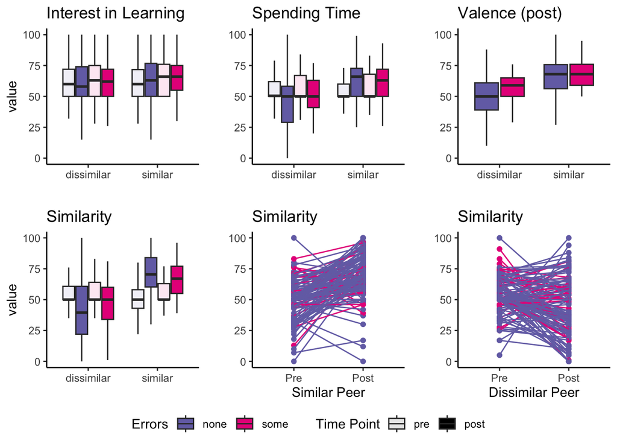

```r
# Define color palette
color_palette <- c("#7570B3", "#E7298A")

plot1 <- ggplot(data = subset(pre_post_data_long_error,
                              question %in% c('learn_simpeer', 'learn_dispeer')),
                aes(x=peer, y=value, fill=errors, alpha=factor(time_point), z=question)) +
         geom_boxplot(outlier.shape = NA) +
         theme_classic() +
         theme(legend.position="none") +
         ggtitle("Interest in Learning") +
         xlab("") +
         scale_fill_manual(values = color_palette) +
         scale_alpha_discrete(guide = guide_legend(override.aes = list(fill = "black"))) +
         labs(alpha = 'Time Point', fill = 'Errors')
plot2 <- ggplot(data = subset(pre_post_data_long_error,
                              question %in% c('time_simpeer', 'time_dispeer')),
                aes(x=peer, y=value, fill=errors, alpha=time_point, z=question)) +
         geom_boxplot(outlier.shape = NA) +
         theme_classic() +
         theme(legend.position="none") +
         ggtitle("Spending Time") +
         xlab("") +
         scale_fill_manual(values = color_palette) +
         ylab("")

plot3 <- ggplot(data = subset(pre_post_data_long_error,
                              question %in% c('similar_simpeer', 'similar_dispeer',
                                              'common_simpeer','common_dispeer')),
                aes(x=peer, y=value, fill=errors, alpha=time_point, z=question)) +
         geom_boxplot(outlier.shape = NA) +
         theme_classic() +
         theme(legend.position="none") +
         ggtitle("Similarity") +
         xlab("") +
         scale_fill_manual(values = color_palette)

plot4 <- ggplot(data = subset(pre_post_data_long_error,
                              question %in% c('similar_simpeer', 'common_simpeer')),
                aes(x=time_point, y=value, group=record_id, color=errors)) +
         geom_point() +
         geom_line() +
         theme_classic() +
         scale_x_discrete(name ="Similar Peer", labels=c("Pre","Post")) +
         theme(legend.position="none") +
         ggtitle("Similarity") +
         scale_color_manual(values = color_palette) +
         ylab("")

plot5 <- ggplot(data = subset(pre_post_data_long_error,
                              question %in% c('similar_dispeer', 'common_dispeer')),
                aes(x=time_point, y=value, group=record_id, color=errors)) +
         geom_point() +
         geom_line() +
         theme_classic() +
         scale_x_discrete(name ="Dissimilar Peer", labels=c("Pre","Post")) +
         theme(legend.position="none") +
         ggtitle("Similarity") +
         scale_color_manual(values = color_palette) +
         ylab("")


plot6 <- ggplot(data = subset(pre_post_data_long_error,
                              question %in% c('feel_simpeer', 'feel_dispeer')),
                aes(x=peer, y=value, fill=errors, z=question)) +
         geom_boxplot(outlier.shape = NA) +
         theme_classic() +
         ggtitle("Valence (post)") +
         xlab("") +
         scale_fill_manual(values = color_palette) +
         ylab("")



ggarrange(plot1, plot2, plot6,
          plot3, plot4, plot5,
          ncol=3, nrow=2, common.legend = TRUE, legend = 'bottom')
```